# Ecosystems Assessment: Midwest Driftless Area Ecological Section

Author

Randy Swaty (rswaty@tnc.org)

Published

September 18, 2026

## Introduction

Principle 6 of the [FSC US Forest Stewardship Standard (FSS)](https://us.fsc.org/forest-management/revised-fscr-us-forest-stewardship-standard-v2) aims to maximize positive environmental impacts and minimize adverse environmental impacts of management activities occurring within certified management units. Toward this desired outcome, Criterion 6.5 requires the identification and protection or restoration of native ecosystems that are not already adequately represented and protected in the landscape, defined here as the Ecological Section named above, and in the locator map to the right.

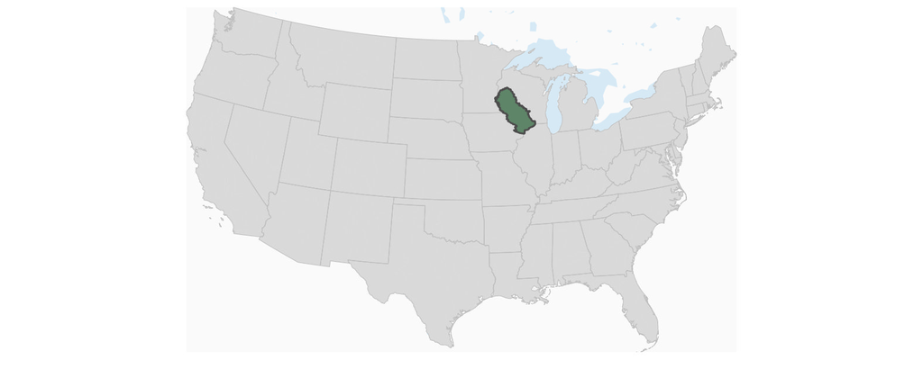

This tool serves to support certificate holders with the requirements of Criterion 6.5 related to Representative Sample Areas (RSAs), but importantly, does not ensure conformance. Additional information gathering and evaluation will most likely be required by certificate holders to ensure conformance with the elements of Criterion 6.5. It is not possible to establish a blanket measurement by which to determine “adequate” protection of all various and complex native ecosystems across the entirety of the conterminous US.

This tool primarily helps with elements of Indicator 6.5.1 and may additionally assist in conformance with Indicators 6.5.2 - 6.5.6. It is deeply aligned with Annex G of the FSC US FSS, which provides guidance for identifying RSAs, as well as guidance for management and activities within RSAs and managing to restore more natural conditions inside or outside of RSAs.

## Historic Native and Existing Vegetation Types

The first step to identifying RSAs (as outlined in Annex G) is to identify native ecosystems that would typically occur in the management unit given current climate and soil conditions. This ﬁrst section helps to identify the historic native ecosystems that should occur in the landscape given the existing climate and soil conditions (an essential element of Indicator 6.5.1). It then helps to identify the existing ecosystems that are currently present within the landscape (using [LANDFIRE](https://landfire.gov/) data).

Importantly, these assessments only cover the top 10 most prevalent ecosystems. For lesser present ecosystems, we suggest reviewing additional data sources such as State Wildlife Action Plans, [NatureServe](https://www.natureserve.org/), or local conservation initiatives to ensure you have a full understanding of the landscape(s) in which your management unit occurs.

This section also provides tables of the percent of the top 3 ecosystem types that should occur given historic data (historic native ecosystems) that remain or are converted to currently present existing ecosystems.

**Note**

We quantified Historic Native Ecosystems using LANDFIRE’s [Biophysical Settings](https://landfire.gov/vegetation/bps) data and Existing Ecosystems using LANDFIRE’s Existing Vegetation Type-Ecological Systems data. See more about these datasets in “Key Concepts” section below.

Due to evolution of methods and naming conventions, the ecosystem names between the Historic Native and Existing ecosystem charts may be different.

### Historic Native Ecosystems Greater than 1,000 acres

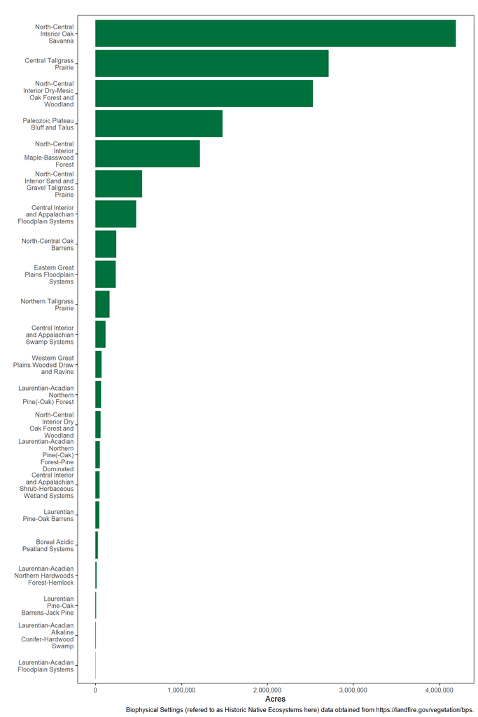

**Historic Native Ecosystems that had less than 1,000 acres in this Ecological Section were: Eastern Great Plains Wet Meadow-Prairie-Marsh; Laurentian-Acadian Shrub-Herbaceous Wetland Systems; Boreal White Spruce-Fir-Hardwood Forest-Inland; Central Interior and Appalachian Riparian Systems; Boreal White Spruce-Fir-Hardwood Forest-Aspen-Birch; Great Lakes Wet-Mesic Lakeplain Prairie.

LANDFIRE data is designed for landscape-level assessments and not designed for analysis of ‘rare’ systems. Please take this into account, explore surronding ecological sections, look to more localized sources of information and use this list with caution. Not all listed ecosystem may have been in this Ecological Section historically.

### Existing Ecosystems - 2024

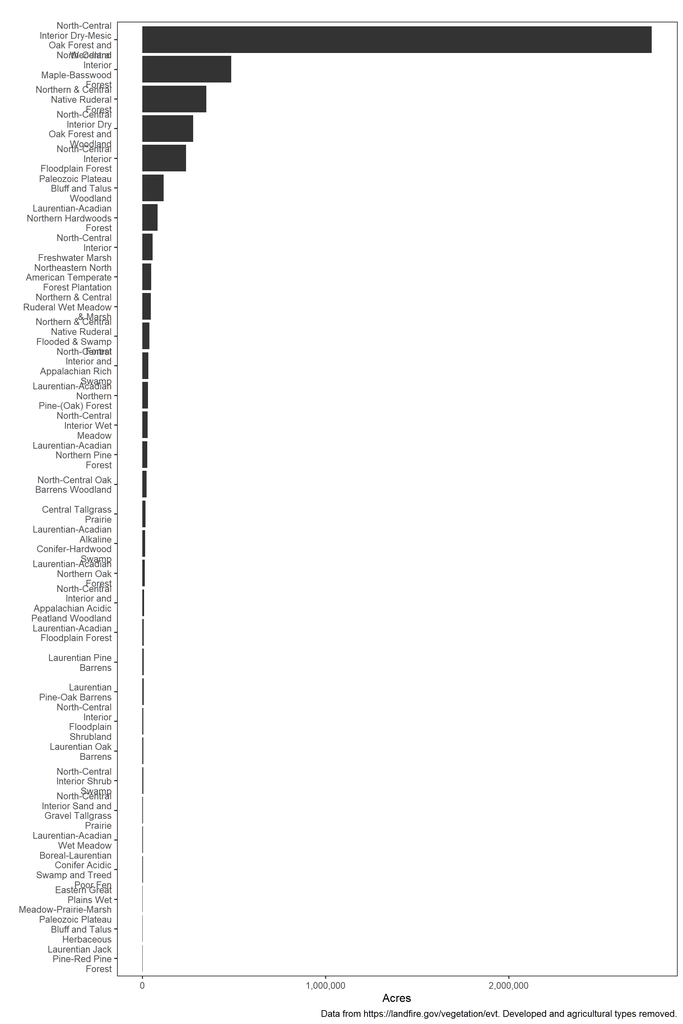

**TipHistoric Native and Existing Ecosystems**

For this Ecological Section:

- LANDFIRE data shows there were **28** Historic Native Ecosystems (by name, there may be more if counting by regional variants).
- The top 10 Historic Native Ecosystems presented here covered **95%** of the total area.
- As of 2024 LANDFIRE mapped **51** Existing Vegetation Types for this Ecological Section.
- The top 10 Existing Ecosystems cover **90%** of the total area.

### Flow chart: Composition of Existing Ecosystems within the three most prevalent Historic Native Ecosystem footprints

For the charts below we assessed the amounts of each Existing Ecosystem (at a coarse level; includes agricultural and developed types) within each of the top 3 most prevalent Native Ecosystem footprints for this Ecological Section.

**Understanding the Sankey charts:**

- The Historic Native Ecosystem is on the left, coarse-level Existing Ecosystems on the right.
- Hover over the grey horizontal bands to explore how Historic Native Ecosystems have split out to the associated Existing Ecosystems on the current landscape.
- The total current percent of each Existing Ecosystem for this Ecological Section quantified in parentheses.

North-Central Interior Oak Savanna (44%)

[interactive chart not shown]

Central Tallgrass Prairie (29%)

[interactive chart not shown]

North-Central Interior Dry-Mesic Oak Forest and Woodland (27%)

[interactive chart not shown]

### Summary Table of Conversion

| Native Ecosystem | Total Area | Natural Vegetation Remaining | Converted (Agriculture + Developed) | Percent Natural Vegetation Remaining | pct_num |
| --- | --- | --- | --- | --- | --- |
| North-Central Interior Oak Savanna | 18,850,296 | 8,322,660 | 10,527,636 | 44.2% | 0.4415134913531331 |
| Central Tallgrass Prairie | 12,200,211 | 2,980,908 | 9,219,303 | 24.4% | 0.2443324955609374 |
| North-Central Interior Dry-Mesic Oak Forest and Woodland | 11,376,895 | 3,462,209 | 7,914,686 | 30.4% | 0.3043193243850805 |
| Paleozoic Plateau Bluff and Talus | 6,655,215 | 3,773,745 | 2,881,470 | 56.7% | 0.5670357757037151 |
| North-Central Interior Maple-Basswood Forest | 5,462,506 | 2,058,146 | 3,404,360 | 37.7% | 0.3767768859201253 |
| North-Central Interior Sand and Gravel Tallgrass Prairie | 2,443,174 | 1,005,454 | 1,437,720 | 41.2% | 0.4115359773802439 |
| Central Interior and Appalachian Floodplain Systems | 2,132,744 | 1,509,786 | 622,958 | 70.8% | 0.7079077470151129 |
| North-Central Oak Barrens | 1,095,603 | 636,086 | 459,517 | 58.1% | 0.5805807395562078 |
| Eastern Great Plains Floodplain Systems | 1,070,050 | 479,930 | 590,120 | 44.9% | 0.4485117517872997 |
| Northern Tallgrass Prairie | 737,376 | 168,357 | 569,019 | 22.8% | 0.2283190665277958 |

[output cut: 12 more lines]

**Note**

**Consideration:** Before moving on to the next section, think through which ecosystems have been most impacted by conversion. If a system has largely been converted to agricultural and developed land uses AND it has low levels of protection below, it may be worth additional consideration.

## GAP Status

**The GAP status codes are defined as (copied from https://www.usgs.gov/programs/gap-analysis-project/gap-status-code-frequently-asked-questions-faq):**

**Gap Status 1:** An area having permanent protection from conversion of natural land cover and a mandated management plan in operation to maintain a natural state within which disturbance events (of natural type, frequency, intensity, and legacy) are allowed to proceed without interference or are mimicked through management.

**Gap Status 2:** An area having permanent protection from conversion of natural land cover and a mandated management plan in operation to maintain a primarily natural state, but which may receive uses or management practices that degrade the quality of existing natural communities, including suppression of natural disturbance.

**Gap Status 3:** An area having permanent protection from conversion of natural land cover for the majority of the area, but subject to extractive uses of either a broad, low intensity type (for example, logging, Off-Highway Vehicle recreation) or localized intense type (for example, mining). It also confers protection to federally listed endangered and threatened species throughout the area.

**GAP status 4 not shown in chart below. Chart is interactive. Hover over bars to get more information.**

[interactive chart not shown]

**Tip**

**Protection Status**

- The lowest observed protection level is **4%**.
- Ecosystems with the least protection include: **Northern & Central Native Ruderal Forest (4%); Laurentian-Acadian Northern Hardwoods Forest (4%); North-Central Interior Dry-Mesic Oak Forest and Woodland (5%)**.
- The lowest level of strict protection (GAP Status 1) is **0.0%**, with the least represented ecosystems including: **Eastern Great Plains Wet Meadow-Prairie-Marsh (0.0%); Laurentian Oak Barrens (0.0%); Laurentian Pine-Oak Barrens (0.0%)**.

## Next Steps – No need to establish RSA(s)

If the result of the assessment conducted using the information above combined with additional research and justification on the part of the certificate holder shows that all native ecosystems are adequately represented or protected in the landscape, then there is no need to establish RSAs within the management unit.

## Next Steps – Need to establish RSA(s)

Per Indicator 6.5.2, if the results of the assessment conducted using the information above combined with additional research and justification on the part of the certificate holder shows that there are native ecosystems that are not adequately represented or protected within the landscape, viable examples of these ecosystems will need to be designated as Representative Sample Areas within the management unit. If there are no viable examples, degraded examples that could be restored need to be designated as RSAs and managed to restore to more natural conditions.

When there is a need for RSAs, designating areas of native ecosystems within your management unit that represent underrepresented successional classes is encouraged, but not required. In these cases, the following sections may be helpful in advising decisions by providing a more in-depth view into levels of representation and protection of different successional classes for each ecosystem.

### Exploration of Successional Classes and Historical Disturbance Amounts for top Native Ecosystems

The table below provides insight into historic vs current succession class amounts for the top native ecosystems in this landscape.

### Reference and Current Succession Class Amounts for top Native Ecosystems

We quantified Historic Native Ecosystems using LANDFIRE’s [Biophysical Settings](https://landfire.gov/vegetation/bps) spatial data, “reference” succession class amounts from LANDFIRE’s [Biophysical Settings Models](https://landfire.gov/vegetation/bps-models), and current amounts of each succession class using LANDFIRE’s (Succession Class)[https://landfire.gov/vegetation/sclass]spatial data. See more about these datasets in “Key Concepts” section below.

**About the charts that follow:**

- We selected the top 10 Historic Native Ecosystems by their unique numerical code for the charts below. Most Historic Native Ecosystems have ‘variants’ representing different reference conditions (e.g., different successional stages and amounts). Therefore there may be multiple charts per BpS name, and each Historic Native Ecosystem in the ‘Native Ecosystems’ chart above may not have a chart below.
- Historic Native Ecosystem (i.e., LANDFIRE Biophysical Settings) descriptions and succession class definitions presented at bottom of report).
- Because the succession classes are custom for each ecosystem the classes are labeled simply as A-E in the chart, plus:
  - UN for “Uncharacteristic Native”, or situations where the vegetation is native, but the structure (i.e., canopy cover and height) currently present was not defined as reference.
  - UE for “Uncharacteristic Exotic” For descriptions of the classes see table below (and documents as well).

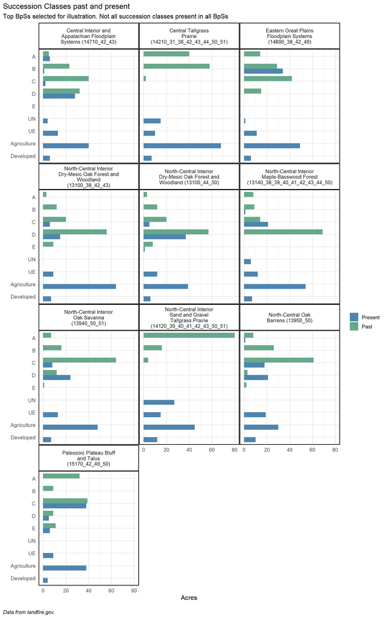

### Annual Historical Disturbance Amounts for top Historic Native Ecosystems

In order to estimate historical amounts of succession classes, LANDFIRE used state and transition modeling with specifics captured in the (Biophysical Settings Models and Descriptions)[https://landfire.gov/vegetation/bps-models]. The transitions in this context are natural disturbances. By multiplying the modeled annual probability by the mapped amount of an BpS, we can estimate annual disturbance amounts.

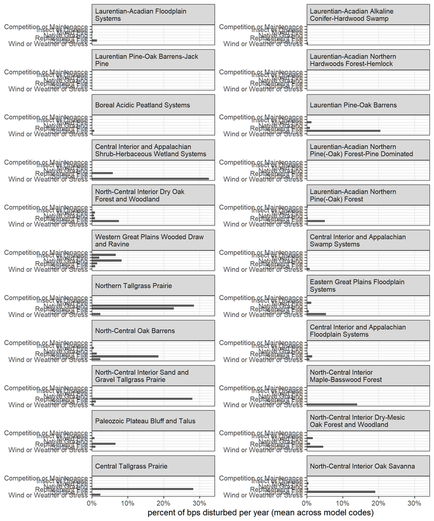

## Key Concepts about the input data from LANDFIRE:

In order to better understand the the quantity of historical ecosystems, their protection status, ecological condition and natural disturbance regimes at a landscape scale, we summarized LANDFIRE and GAP data to Ecological Sections. These summaries are coarse, aimed at setting context and setting the stage for structured analysis of more local management areas.

**Key Concepts about the input data:**

In order to better understand the quantity of historic ecosystems, their protection status, ecological condition and natural disturbance regimes at a landscape scale, we summarized LANDFIRE and GAP data to Ecological Sections. These summaries are coarse, aimed at setting context and setting the stage for structured analysis of more local management areas.

- The Biophysical Settings (BpS) data represents the “habitat” of an ecosystem, based on abiotic factors such as soils, surficial geology, slope, elevation and aspect, plus the current climate. Each BpS has a reference document that describes how it looked and functioned prior to European colonization and a state-and-transition model that estimates how much of each “Succession Class” (see below) would have occurred within the habitat based on best approximations of the natural disturbance regime (referred to below as ‘reference’). The BpSs are based on NatureServe’s Ecological Systems. This data represents ecosystems that “should” occur in the landscape. We call these Historic Native Ecosystems.
- Succession Classes (s-class) are essentially developmental and/or structural stages. There are up to 5 defined for each BpS and are based on lifeform (e.g., broadleaf or needleleaf), and ranges of canopy cover (e.g., 70-80%) and canopy height (e.g., 10-25M ). In addition to modeled estimates of reference percents of each SCL, succession classes are mapped across the US today so that we can compare reference to current amounts.
- Existing Vegetation Type (EVT) data represents the current distribution of NatureServe’s Ecological Systems. Because of subsequent review and improvement, BpS and EVT names and lists for particular places may not always match. This data represents ecosystems that occur in the landscape. [CE9.1]. We call these Existing Ecosystems.
- GAP Status data identifies the level of biodiversity protection provided to ecosystems based on management intent and legal mandates. This information helps assess the extent to which Existing Ecosystems are represented within lands managed for long-term conservation of biodiversity.

## Historic Native Ecosystem Descriptions and Succession Class Definitions

To better understand ‘reference’ conditions for the Historic Native Ecosystems of the US, the LANDFIRE program developed descriptions plus accompanying state-and-transition models that depict how these systems ‘looked and functioned’ with natural disturbance regimes. Below you can download the descriptions for the dominant Native Ecosystems and explore the succession class descriptions in a table.

LANDFIRE developed and delivers this information by Map Zone. If an ecosystem crosses multiple Map Zones there may be multiple ‘variants’. In the table of links to the descriptions you will see “Model Codes”, which represent an unique 5 digit code for the system followed by a list of Map Zones that description applies to.

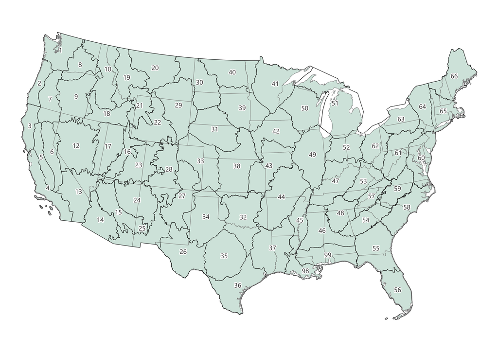

LANDFIRE Map Zones for the lower 48 states

| Native Ecosystem | Model Code | Document |
| --- | --- | --- |
| North-Central Interior Dry-Mesic Oak Forest and Woodland | 13100_38_42_43 | North-Central Interior Dry-Mesic Oak Forest and Woodland (13100_38_42_43) |
| North-Central Interior Dry-Mesic Oak Forest and Woodland | 13100_44_50 | North-Central Interior Dry-Mesic Oak Forest and Woodland (13100_44_50) |
| North-Central Interior Maple-Basswood Forest | 13140_38_39_40_41_42_43_44_50 | North-Central Interior Maple-Basswood Forest (13140_38_39_40_41_42_43_44_50) |
| North-Central Interior Oak Savanna | 13940_50_51 | North-Central Interior Oak Savanna (13940_50_51) |
| North-Central Oak Barrens | 13950_50 | North-Central Oak Barrens (13950_50) |
| North-Central Interior Sand and Gravel Tallgrass Prairie | 14120_39_40_41_42_43_50_51 | North-Central Interior Sand and Gravel Tallgrass Prairie (14120_39_40_41_42_43_50_51) |
| Central Tallgrass Prairie | 14210_31_38_42_43_44_50_51 | Central Tallgrass Prairie (14210_31_38_42_43_44_50_51) |
| Eastern Great Plains Floodplain Systems | 14690_38_42_49 | Eastern Great Plains Floodplain Systems (14690_38_42_49) |
| Central Interior and Appalachian Floodplain Systems | 14710_42_43 | Central Interior and Appalachian Floodplain Systems (14710_42_43) |
| Paleozoic Plateau Bluff and Talus | 15170_42_49_50 | Paleozoic Plateau Bluff and Talus (15170_42_49_50) |

As noted above each Historic Native Ecosystem has up to 5 succession classes, and each one has unique descriptions and mapping rules. Those descriptions and mapping rules for the Historic Native Ecosystems presented in the Succession Class Chart are presented below.

| Native Ecosystem Name | BpS Model | Class label | Short description | Full description | sort_id |
| --- | --- | --- | --- | --- | --- |
| North-Central Interior Dry-Mesic Oak Forest and Woodland | 13100_38_42_43 | A | Early1:ALL | G rassland prairie maintained by frequently recurring fire. Native Americans used these lands for hunting, and agriculture/native plant gathering. If fire is absent for a few years, tree seedlings and… | Early1:ALL |
| North-Central Interior Dry-Mesic Oak Forest and Woodland | 13100_38_42_43 | B | Mid1:OPN | SAVANNA. Savannas conditions occurred where fire was fairly frequent allowing some trees to develop (5-15 yrs ). Any area that does not burn frequently would convert to woodland conditio ns (class C).… | Mid1:OPN |
| North-Central Interior Dry-Mesic Oak Forest and Woodland | 13100_38_42_43 | C | Mid2:OPN | WOODLAND. This class ranges in age from 15-24yrs and succeeds to class D in the absence of disturbance. The canopy closure was less than 60%. | Mid2:OPN |
| North-Central Interior Dry-Mesic Oak Forest and Woodland | 13100_38_42_43 | D | Mid3:CLS | OAK FOREST. The age class lasts indefinitely as long as surface fire occurs periodically. If the late-succession open forest type persists for 50yrs without any type of fire, it will convert to a late… | Mid3:CLS |
| North-Central Interior Dry-Mesic Oak Forest and Woodland | 13100_38_42_43 | E | Late1:CLS | MESOPHYTIC FOREST. Maple forests develop during the absence of fire. Dense understories of shade-tolerant species develop. These systems often arise on more moist sites adjacent to/on lee sides of str… | Late1:CLS |
| North-Central Interior Dry-Mesic Oak Forest and Woodland | 13100_44_50 | A | Early1:ALL | Prairie. Class A is grassland prairie maintained by frequently recurring fire. If fire is absent for a few years, tree seedlings and sprouts would recruit into trees and form savannas. Heavy grazing, … | Early1:ALL |
| North-Central Interior Dry-Mesic Oak Forest and Woodland | 13100_44_50 | B | Mid1:OPN | Savanna . Savanna conditions occurred where fire was fairly frequent , allowing some trees to develop . | Mid1:OPN |
| North-Central Interior Dry-Mesic Oak Forest and Woodland | 13100_44_50 | C | Mid2:OPN | Woodland . This class is defined as oak woodland where fire occurred every 15- 25 yrs . The canopy closure was &lt; 80 %. | Mid2:OPN |
| North-Central Interior Dry-Mesic Oak Forest and Woodland | 13100_44_50 | D | Mid3:CLS | Oak forest . Class D is defined as oak forest. The age class is 51 indefinite years as long as surface fire occurs periodically. If the late-succession open forest type persists for 50yrs without any … | Mid3:CLS |
| North-Central Interior Dry-Mesic Oak Forest and Woodland | 13100_44_50 | E | Late2:CLS | Mesophytic forest. Mesic forests develop during the absence of fire. Dense understories of shade-tolerant species develop. | Late2:CLS |

[output cut: 33 more lines]